# HW2

Davis Vaughan

1/26/2018

## Load required packages

If you want to run the code, you will need the packages below. To install them you would have to do the code that is commented out. If you have any questions, let me know!

```r
library(dplyr)
library(lubridate)
library(tidyquant)
options(pillar.sigfig = 6)

# To install the above packages if you don't have them:
# install.packages("dplyr")
# install.packages("lubridate")
# install.packages("devtools")
# devtools::install_github("business-science/tidyquant")
```

## Initialize variables

```r
# 100 shares of SPY
shares_spy <- 100

# 400 European put options on Apple
options_appl   <- 400
time_to_expiry <- 1
sigma          <- .25    # volatility
k              <- 170    # strike
r              <- .012   # risk free int rate
y              <- .019   # div yield

# Dates
end_date   <- as.Date("2018-01-05")
start_date <- end_date - years(2) + days(2) # Add two days to get the correct 504 prices
```

## Retrieve data

Based on the HW notes, “most recent AAPL price of 175” implies that he used closing prices, because that is the only one that fits.

```r
spy  <- tq_get("SPY",  from = start_date, to = end_date, get = "stock.prices.google") %>%
  select(date, close) %>%
  rename(spy_close = close)

spy
```

```
## # A tibble: 504 x 2
##    date       spy_close
##    <date>         <dbl>
##  1 2016-01-07    194.05
##  2 2016-01-08    191.92
##  3 2016-01-11    192.11
##  4 2016-01-12    193.66
##  5 2016-01-13    188.83
##  6 2016-01-14    191.93
##  7 2016-01-15    187.81
##  8 2016-01-19    188.06
##  9 2016-01-20    185.65
## 10 2016-01-21    186.69
## # ... with 494 more rows
```

```r
aapl <- tq_get("AAPL", from = start_date, to = end_date, get = "stock.prices.google") %>%
  select(date, close)

aapl
```

```
## # A tibble: 504 x 2
##    date         close
##    <date>       <dbl>
##  1 2016-01-07 96.4500
##  2 2016-01-08 96.9600
##  3 2016-01-11 98.5300
##  4 2016-01-12 99.9600
##  5 2016-01-13 97.3900
##  6 2016-01-14 99.5200
##  7 2016-01-15 97.1300
##  8 2016-01-19 96.6600
##  9 2016-01-20 96.7900
## 10 2016-01-21 96.3000
## # ... with 494 more rows
```

## Black scholes pricing function

```r
put_option_pricer <- function(s, k, r, y, t, sigma) {

  d1 <- (log(s / k) + (r - y + sigma^2 / 2) * t) / (sigma * sqrt(t))
  d2 <- d1 - sigma * sqrt(t)

  V <- pnorm(-d2) * k * exp(-r * t) - s * exp(-y * t) * pnorm(-d1)

  V
}
```

## More setup

```r
# 99th percentile on 503 values
percentile_99 <- round((nrow(aapl) - 1) * 0.01)

percentile_99
```

```
## [1] 5
```

Also important are the current value of Apple and SPY. And the current value of the put option on Apple.

```r
# Current value of AAPL and SPY
current_close_aapl <- last(aapl$close)
current_close_aapl
```

```
## [1] 175
```

```r
current_close_spy  <- last(spy$spy_close)
current_close_spy
```

```
## [1] 273.42
```

```r
# Current put option value of AAPL
current_option_value <- put_option_pricer(current_close_aapl, k , r, y, time_to_expiry, sigma)
current_option_value
```

```
## [1] 15.09287
```

## Calculate relative and absolute differences

Go ahead and calculate separate data frames for absolute differences of Apple and SPY. These will be useful to us later.

For SPY, calculating the deltaX values (absolute shifts) is the same as calculing the deltaP values of a single share of SPY. For Apple, we need to also estimate the shifted option value price.

```r
# Apple absolute shifts
aapl_abs <- aapl %>%
  mutate(delta_close = close - lag(close))

aapl_abs
```

```
## # A tibble: 504 x 3
##    date         close delta_close
##    <date>       <dbl>       <dbl>
##  1 2016-01-07 96.4500   NA
##  2 2016-01-08 96.9600    0.510000
##  3 2016-01-11 98.5300    1.57000
##  4 2016-01-12 99.9600    1.43000
##  5 2016-01-13 97.3900  - 2.57000
##  6 2016-01-14 99.5200    2.13000
##  7 2016-01-15 97.1300  - 2.39000
##  8 2016-01-19 96.6600  - 0.470000
##  9 2016-01-20 96.7900    0.130000
## 10 2016-01-21 96.3000  - 0.490000
## # ... with 494 more rows
```

```r
# Spy absolute shifts
# For SPY, the shifts (delta_x) are the delta_p values
spy_abs <- spy %>%
  mutate(spy_delta_p = spy_close - lag(spy_close))

spy_abs
```

```
## # A tibble: 504 x 3
##    date       spy_close spy_delta_p
##    <date>         <dbl>       <dbl>
##  1 2016-01-07    194.05   NA
##  2 2016-01-08    191.92  - 2.13000
##  3 2016-01-11    192.11    0.190000
##  4 2016-01-12    193.66    1.55000
##  5 2016-01-13    188.83  - 4.83000
##  6 2016-01-14    191.93    3.10000
##  7 2016-01-15    187.81  - 4.12000
##  8 2016-01-19    188.06    0.250000
##  9 2016-01-20    185.65  - 2.41000
## 10 2016-01-21    186.69    1.04000
## # ... with 494 more rows
```

## 1 - Jarque Bera

```r
# Sample skewness
skewness <- function(x, na.rm = FALSE) {

  if(na.rm) {
    x <- na.omit(x)
  }

  n <- length(x)

  numerator   <-  sum( (x - mean(x)) ^ 3 ) / n
  denominator <- (sum( (x - mean(x)) ^ 2 ) / n) ^ (3 / 2)

  numerator / denominator
}

# Sample kurtosis
kurtosis <- function(x, na.rm = FALSE) {

  if(na.rm) {
    x <- na.omit(x)
  }

  n <- length(x)

  numerator   <-  sum( (x - mean(x)) ^ 4 ) / n
  denominator <- (sum( (x - mean(x)) ^ 2 ) / n) ^ 2

  numerator / denominator
}

# Statistic
jarque_bera_stat <- function(x) {

  if(any(is.na(x))) {
    stop("NA values in x")
  }

  1/6 * length(x) * (skewness(x) ^ 2 + 1/4 * (kurtosis(x) - 3) ^ 2)
}

# P-value
jarque_bera_pval <- function(x) {
  stat <- jarque_bera_stat(x)
  pval <- 1 - pchisq(stat, df = 2)
  pval
}
```

Calculate the daily price changes and the log returns and apply our jarque bera stats.

You said “price change,” but I included the arithmetic return as well in case that is what you meant.

Definitely NOT normal! p-values are all 0

```r
spy %>%
  # Rename so you can combine them easier
  rename(close = spy_close) %>%
  bind_rows(spy = ., aapl = aapl, .id = "asset") %>%
  group_by(asset) %>%

  # For SPY and AAPL, calculate price changes and log returns
  mutate(price_change      = close - lag(close),
         arithmetic_return = price_change / lag(close),
         log_return        = log(close / lag(close))) %>%

  # Tidy
  gather(delta_type, delta, price_change, arithmetic_return, log_return) %>%
  group_by(delta_type, add = TRUE) %>%

  # Remove the rows of NAs
  na.omit() %>%

  # Calc JQ values
  summarise(jq_stat = jarque_bera_stat(delta),
            jq_pval = jarque_bera_pval(delta)) %>%
  arrange(desc(delta_type))
```

```
## # A tibble: 6 x 4
## # Groups:   asset [2]
##   asset delta_type        jq_stat jq_pval
##   <chr> <chr>               <dbl>   <dbl>
## 1 aapl  price_change       301.19       0
## 2 spy   price_change       269.19       0
## 3 aapl  log_return         566.15       0
## 4 spy   log_return         407.99       0
## 5 aapl  arithmetic_return  550.41       0
## 6 spy   arithmetic_return  378.57       0
```

# 2 - Analytical 99% VaR under normal assumption

```r
# Required for delta/gamma analytical
d1 <- (log(current_close_aapl / k) + (r - y + sigma^2 / 2) * time_to_expiry) / (sigma * sqrt(time_to_expiry))

# Put delta and gamma
delta_analytical_aapl <- exp(-y * time_to_expiry) * (pnorm(d1) - 1)
delta_analytical_aapl
```

```
## [1] -0.4078595
```

```r
# The SPY analytical delta is just 1 because we aren't dealing with options
delta_analytical_spy <- 1

moments <- aapl_abs %>%
  left_join(spy_abs, "date") %>%
  na.omit() %>%
  summarise(

    # Means
    mu_delta_X_spy   = mean(spy_delta_p),
    mu_delta_X_aapl  = mean(delta_close),
    mu_delta_p       = (delta_analytical_spy  * mu_delta_X_spy  * shares_spy) +
                       (delta_analytical_aapl * mu_delta_X_aapl * options_appl),

    # Variances / Covariances
    var_delta_X_spy  = var(spy_delta_p),
    var_delta_X_aapl = var(delta_close),
    cov_delta_X      = cov(spy_delta_p, delta_close),
    var_delta_p      = (shares_spy   ^ 2 * delta_analytical_spy  ^ 2 * var_delta_X_spy) +
                       (options_appl ^ 2 * delta_analytical_aapl ^ 2 * var_delta_X_aapl) +
                       (2 * shares_spy * options_appl * delta_analytical_aapl * delta_analytical_spy * cov_delta_X)
  )


moments %>%
  mutate(VaR_99 = mu_delta_p + sqrt(var_delta_p) * qnorm(.01)) %>%
  gather(feature, value)
```

```
## # A tibble: 8 x 2
##   feature                  value
##   <chr>                    <dbl>
## 1 mu_delta_X_spy        0.157793
## 2 mu_delta_X_aapl       0.156163
## 3 mu_delta_p       -    9.69771
## 4 var_delta_X_spy       1.88618
## 5 var_delta_X_aapl      2.51093
## 6 cov_delta_X           1.11908
## 7 var_delta_p       49178
## 8 VaR_99           -  525.59
```

# 3 - Beginner VaR

```r
set.seed(123)

n_sims <- 5000
percentile_99_n_sims <- .01 * n_sims

current_portf_value <- shares_spy * current_close_spy + options_appl * current_option_value

cov_mat <- matrix(c(moments$var_delta_X_spy, moments$cov_delta_X,
                    moments$cov_delta_X,     moments$var_delta_X_aapl),
                  nrow = 2,
                  dimnames = list(c("SPY", "AAPL"), c("SPY", "AAPL")))

mean_vec <- matrix(c(moments$mu_delta_X_spy, moments$mu_delta_X_aapl), nrow = 2, dimnames = list(c("SPY", "AAPL")))

chol_fac <- t(chol(cov_mat))

sims <- tibble(
       sim                     = seq(n_sims),
       Z                       = replicate(n_sims, rnorm(2) %>% as.matrix(), simplify = FALSE),
       delta_X                 = map(Z, ~mean_vec + chol_fac %*% .x),
       shifted_aapl            = map_dbl(delta_X, ~current_close_aapl + .x["AAPL",]),
       shifted_spy             = map_dbl(delta_X, ~current_close_spy + .x["SPY",]),
       shifted_aapl_option     = put_option_pricer(shifted_aapl, k , r, y, time_to_expiry, sigma),
       shifted_portfolio_value = shares_spy * shifted_spy + options_appl * shifted_aapl_option,
       delta_P                 = shifted_portfolio_value - current_portf_value
)

sims
```

```
## # A tibble: 5,000 x 8
##      sim Z          delta_X     shifted_aapl shifted_spy shifted_aapl_opt…
##    <int> <list>     <list>             <dbl>       <dbl>             <dbl>
##  1     1 <dbl [2 ×… <dbl [2 × …       174.39      272.81           15.3447
##  2     2 <dbl [2 ×… <dbl [2 × …       176.52      275.72           14.4822
##  3     3 <dbl [2 ×… <dbl [2 × …       177.59      273.75           14.0647
##  4     4 <dbl [2 ×… <dbl [2 × …       173.81      274.21           15.5834
##  5     5 <dbl [2 ×… <dbl [2 × …       173.99      272.63           15.5089
##  6     6 <dbl [2 ×… <dbl [2 × …       176.64      275.26           14.4347
##  7     7 <dbl [2 ×… <dbl [2 × …       175.63      274.13           14.8364
##  8     8 <dbl [2 ×… <dbl [2 × …       177.13      272.81           14.2432
##  9     9 <dbl [2 ×… <dbl [2 × …       172.89      274.26           15.9734
## 10    10 <dbl [2 ×… <dbl [2 × …       175.09      274.54           15.0582
## # ... with 4,990 more rows, and 2 more variables:
## #   shifted_portfolio_value <dbl>, delta_P <dbl>
```

```r
sims %>%
  pull(delta_P) %>%
  sort() %>%
  .[percentile_99_n_sims]
```

```
## [1] -502.6028
```

# 4 - Barrier VaR

Assuming you also want absolute shifts here.

Up and out call formula

```r
up_and_out_call_pricer <- function(s, k, b, r, y, t, sigma) {

  # This formula will actually calculate a value for the option
  # if we don't ceiling it at b. When s == b the value is 0. When s > b
  # the value should also be 0, this ensures that happens.
  s <- pmin(s, b)

  # Call option pricer
  C <- function(s, k) {
      d1 <- (log(s / k) + (r - y + sigma^2 / 2) * t) / (sigma * sqrt(t))
      d2 <- d1 - sigma * sqrt(t)

      s * exp(-y * t) * pnorm(d1) - pnorm(d2) * k * exp(-r * t)
  }

  # Digital call option pricer
  C_d <- function(s, k) {
    numerator   <- log(s / k) + (r - y - .5 * sigma ^ 2) * t
    denominator <- sigma * sqrt(t)

    exp(- r * t) * pnorm(numerator / denominator)
  }

  alpha <- - (r - y - sigma^2 / 2) / (sigma ^ 2)

  V <- C(s, k) - C(s, b) - (b - k) * C_d(s, b) -
      (s / b) ^ (2 * alpha) * ( C(b^2/s, k) - C(b^2/s, b) - (b - k) * C_d(b^2/s, b) )

  V
}
```

```r
b <- 183
current_up_and_out_call_aapl <- up_and_out_call_pricer(current_close_aapl, k, b, r, y, time_to_expiry, sigma)
current_up_and_out_call_aapl
```

```
## [1] 0.02489043
```

```r
from <- 175
to <- 185
by <- .1
```

# 4a - Full reeval

```r
sensitivity_analysis_full_reeval <- function(from_close_price, to_close_price, by, current_up_and_out_call_aapl,
                                             k, b, r, y, time_to_expiry, sigma) {
  tibble(new_close_price = seq(from_close_price, to_close_price, by)) %>%
      mutate(shifted_option_price = up_and_out_call_pricer(new_close_price, k, b, r, y, time_to_expiry, sigma),
             P_and_L    = shifted_option_price - current_up_and_out_call_aapl) %>%
    select(new_close_price, P_and_L)
}

PL_full_reeval <- sensitivity_analysis_full_reeval(from, to, by, current_up_and_out_call_aapl, k, b, r, y, time_to_expiry, sigma)

PL_full_reeval
```

```
## # A tibble: 101 x 2
##    new_close_price      P_and_L
##              <dbl>        <dbl>
##  1          175.00  0
##  2          175.10 -0.000299611
##  3          175.20 -0.000599641
##  4          175.30 -0.000900085
##  5          175.40 -0.00120094
##  6          175.50 -0.00150220
##  7          175.60 -0.00180385
##  8          175.70 -0.00210590
##  9          175.80 -0.00240835
## 10          175.90 -0.00271117
## # ... with 91 more rows
```

# 4b - DG Approx

```r
sensitivity_analysis_dg <- function(from_close_price, to_close_price, by, current_close_aapl,
                                             k, b, r, y, time_to_expiry, sigma) {

  range_close_price <- seq(from_close_price, to_close_price, by)
  delta_close <- range_close_price - current_close_aapl

  # Calculate h for absolute
  h <- sqrt(var(delta_close) + mean(delta_close) ^ 2)

  # Recalculate the put options with a shock upward
  shift_up_close   <- up_and_out_call_pricer(current_close_aapl + h, k, b, r, y, time_to_expiry, sigma)

  # Recalculate the put options with a shock downward
  shift_down_close <- up_and_out_call_pricer(current_close_aapl - h, k, b, r, y, time_to_expiry, sigma)

  # This is P in the formula, used by gamma
  no_shift_close   <- up_and_out_call_pricer(current_close_aapl, k, b, r, y, time_to_expiry, sigma)

  # Approximate delta
  delta_numerical  <- (shift_up_close - shift_down_close) / (2 * h)

  # Approximate gamma
  gamma_numerical  <- (shift_up_close - 2 * no_shift_close + shift_down_close) / (h^2)

  tibble(new_close_price = range_close_price,
         delta_close     = delta_close,
         P_and_L         = delta_numerical * delta_close + 1/2 * gamma_numerical * delta_close ^ 2) %>%
    select(new_close_price, P_and_L)
}

PL_dg <- sensitivity_analysis_dg(from, to, by, current_close_aapl, k, b, r, y, time_to_expiry, sigma)

PL_dg
```

```
## # A tibble: 101 x 2
##    new_close_price      P_and_L
##              <dbl>        <dbl>
##  1          175.00  0
##  2          175.10 -0.000296857
##  3          175.20 -0.000594138
##  4          175.30 -0.000891843
##  5          175.40 -0.00118997
##  6          175.50 -0.00148853
##  7          175.60 -0.00178750
##  8          175.70 -0.00208690
##  9          175.80 -0.00238673
## 10          175.90 -0.00268698
## # ... with 91 more rows
```

## 4c - Grid

```r
sensitivity_analysis_grid <- function(from_close_price, to_close_price, by, current_close_aapl,
                                             k, b, r, y, time_to_expiry, sigma) {

  grid_multipliers <- c(.6, .7, .8, .9, .95, .99, 1, 1.01, 1.05, 1.1, 1.2, 1.3, 1.4)
  grid_prices      <- grid_multipliers * current_close_aapl
  grid_options     <- up_and_out_call_pricer(grid_prices, k, b, r, y, time_to_expiry, sigma)

  current_up_and_out_call_aapl <- up_and_out_call_pricer(current_close_aapl, k, b, r, y, time_to_expiry, sigma)

  tibble(new_close_price  = seq(from_close_price, to_close_price, by),
         new_option_value = approx(x = grid_prices, y = grid_options, xout = new_close_price)$y,
         P_and_L          = new_option_value - current_up_and_out_call_aapl) %>%
    select(new_close_price, P_and_L)
}

PL_grid <- sensitivity_analysis_grid(from, to, by, current_close_aapl, k, b, r, y, time_to_expiry, sigma)

PL_grid
```

```
## # A tibble: 101 x 2
##    new_close_price      P_and_L
##              <dbl>        <dbl>
##  1          175.00  0
##  2          175.10 -0.000302858
##  3          175.20 -0.000605716
##  4          175.30 -0.000908574
##  5          175.40 -0.00121143
##  6          175.50 -0.00151429
##  7          175.60 -0.00181715
##  8          175.70 -0.00212000
##  9          175.80 -0.00242286
## 10          175.90 -0.00272572
## # ... with 91 more rows
```

As you can see, the P and L for DG overshoots the Full reevaluation as the new price approaches the barrier. The grid approach stops at 0, but is slower in getting there.

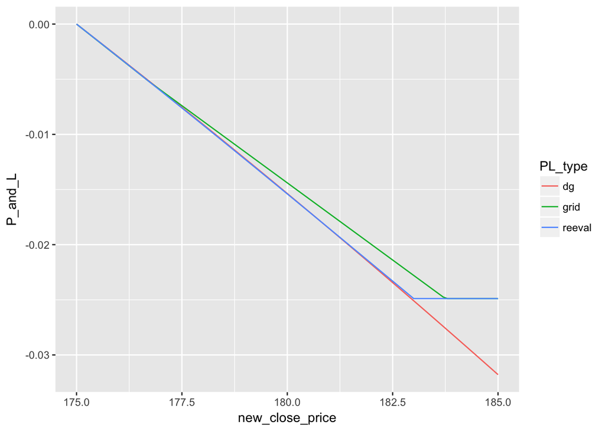

```r
all_P_and_L <- bind_rows(list(reeval = PL_full_reeval, dg = PL_dg, grid = PL_grid), .id = "PL_type")

all_P_and_L %>%
  ggplot(aes(x = new_close_price, y = P_and_L, color = PL_type)) +
  geom_line()
```